# Scatterplots

Let’s start by importing `seaborn` and loading/previewing our iris data

```python
# import seaborn
import seaborn as sns
# set up for inline plotting
%matplotlib inline
```

```python
# load iris and preview the data
iris = sns.load_dataset("iris")
iris.head(10)
```

|  | sepal_length | sepal_width | petal_length | petal_width | species |
| --- | --- | --- | --- | --- | --- |
| 0 | 5.1 | 3.5 | 1.4 | 0.2 | setosa |
| 1 | 4.9 | 3.0 | 1.4 | 0.2 | setosa |
| 2 | 4.7 | 3.2 | 1.3 | 0.2 | setosa |
| 3 | 4.6 | 3.1 | 1.5 | 0.2 | setosa |
| 4 | 5.0 | 3.6 | 1.4 | 0.2 | setosa |
| 5 | 5.4 | 3.9 | 1.7 | 0.4 | setosa |
| 6 | 4.6 | 3.4 | 1.4 | 0.3 | setosa |
| 7 | 5.0 | 3.4 | 1.5 | 0.2 | setosa |
| 8 | 4.4 | 2.9 | 1.4 | 0.2 | setosa |
| 9 | 4.9 | 3.1 | 1.5 | 0.1 | setosa |

In the last lesson we examined the relationship between `sepal_length` and `sepal_width`. Now let’s look at this relationship for `petal_length` and `petal_width` using a scatterplot.

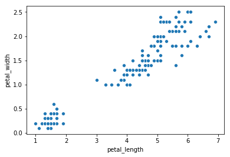

```python
# plot petal_length vs petal_width
sns.scatterplot('petal_length', 'petal_width', data=iris)
```

This relationship is definitely more clear without any stratification than our last example in the lesson. Let’s create this plot with a **correlation trendline** to visualize the trend even better.

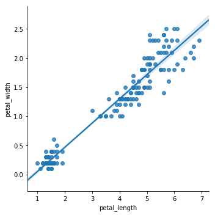

```python
# plot petal_length vs petal_width with trendline
sns.lmplot('petal_length', 'petal_width', data=iris)
```

Now let’s *stratify* the plot by the `species` variable, using **both** color and marker shape.

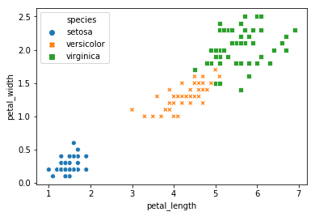

```python
# plot petal_length vs petal_width
sns.scatterplot('petal_length', 'petal_width', hue='species', style = 'species',data=iris)
```

We can very clearly see the separation of our three species across these two variables.

Now, let’s color our graph using the `sepal_length` variable (no marker shape). What do you notice about the way the graph is colored now?

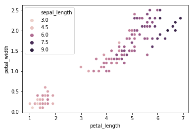

```python
# plot petal_length vs petal_width
sns.scatterplot('petal_length', 'petal_width', hue='sepal_length', data=iris)
```

Notice that `sepal_length` is a *continuous* variable, compared to the *categorical* variable `species` we originally used to color our plot. Seaborn can tell the difference by examining the `type` of the stratifying variable - `int` and `float` variables are *continuous* and `string` and `boolean` variables are seen as *categorical*.

It is important to consider variable type when choosing the color palette to use in our plots. *Continuous* variables require *sequential* color palettes (that go from light to dark shades, for example) and *categorical* variables require *qualitative* color palettes. You can find built-in seaborn color palettes here: https://seaborn.pydata.org/tutorial/color_palettes.html

After looking through the link above, choose a new **appropriate** color palette for the plot above.

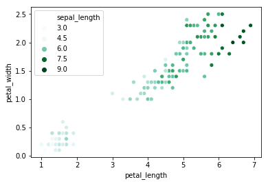

```python
# plot petal_length vs petal_width
sns.scatterplot('petal_length', 'petal_width', hue='sepal_length', palette="BuGn" ,data=iris)
```

Based on this plot, what can you tell about the relationship of `sepal_length` compared to `petal_length`, `petal_width`?